# HMW 1- Data 621

OMER OZEREN

## Introduction

I have been given a dataset with 2276 records summarizing a major league baseball team’s season. All statistics have been adjusted to match the performance of a 162 game season. The objective is to build a linear regression model to predict the number of wins for a team. This report covers an attempt to build a model to predict number of wins of a baseball team in a season based on several offensive and deffensive statistics. Resulting model explained about 36% of variability in the target variable and included most of the provided explanatory variables. Some potentially variables were not included in the data set due to missing values.I used KNN for variable missing values imputtion.

## DATA EXPLORATION

Each record in the data set represents the performance of the team for the given year adjusted to the current length of the season - 162 games. The data set includes 16 variables and the training set includes 2,276 records. Following Table show variable Statistical DEscriptions :

|  | Min | Median | Mean | SD | Max | Num of Zeros | Num of NaN |
| --- | --- | --- | --- | --- | --- | --- | --- |
| TARGET_WINS | 0 | 82.0 | 81 | 16 | 146 | 1 | 0 |
| TEAM_BATTING_H | 891 | 1454.0 | 1469 | 145 | 2554 | 0 | 0 |
| TEAM_BATTING_2B | 69 | 238.0 | 241 | 47 | 458 | 0 | 0 |
| TEAM_BATTING_3B | 0 | 47.0 | 55 | 28 | 223 | 2 | 0 |
| TEAM_BATTING_HR | 0 | 102.0 | 100 | 61 | 264 | 15 | 0 |
| TEAM_BATTING_BB | 0 | 512.0 | 502 | 123 | 878 | 1 | 0 |
| TEAM_BATTING_SO | 0 | 750.0 | 736 | 249 | 1399 | 20 | 102 |
| TEAM_BASERUN_SB | 0 | 101.0 | 125 | 88 | 697 | 2 | 131 |
| TEAM_BASERUN_CS | 0 | 49.0 | 53 | 23 | 201 | 1 | 772 |
| TEAM_BATTING_HBP | 29 | 58.0 | 59 | 13 | 95 | 0 | 2085 |

[output cut: 6 more lines]

Some initial observations:

- The response variable (`TARGET_WINS`) looks to be normally distributed. This supports the working theory that there are good teams and bad teams. There are also a lot of average teams.
- There are also quite a few variables with missing values. We may need to deal with these in order to have the largest data set possible for modeling.
- A couple variables are bimodal (`TEAM_BATTING_HR`, `TEAM_BATTING_SO` `TEAM_PITCHING_HR`). This may be a challenge as some of them are missing values and that may be a challenge in filling in missing values.
- Some variables are right skewed (`TEAM_BASERUN_CS`, `TEAM_BASERUN_SB`, etc.). This might support the good team theory. It may also introduce non-normally distributed residuals in the model. We shall see.

#### Correlations Matrix Table

[figure not shown]

```r
training %>%
  cor(., use = "complete.obs") %>%
  corrplot(., method = "number", type = "upper", tl.col = "black", diag = FALSE)
```

#### Correlations Matrix Plots

Let’s take a look at the correlations. The following is the correlations from the complete cases only:

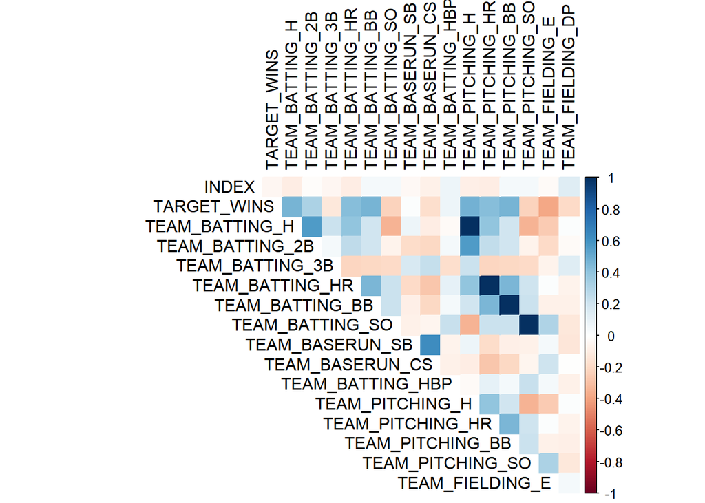

```r
training %>%
  cor(., use = "complete.obs") %>%
  corrplot(., method = "color", type = "upper", tl.col = "black", diag = FALSE)
```

#### Correlations: Endogenous and Exogenous Variables

Let’s take a look at how the Exogenous(Model Inputs) are correlated with the response variable(Endogenous):

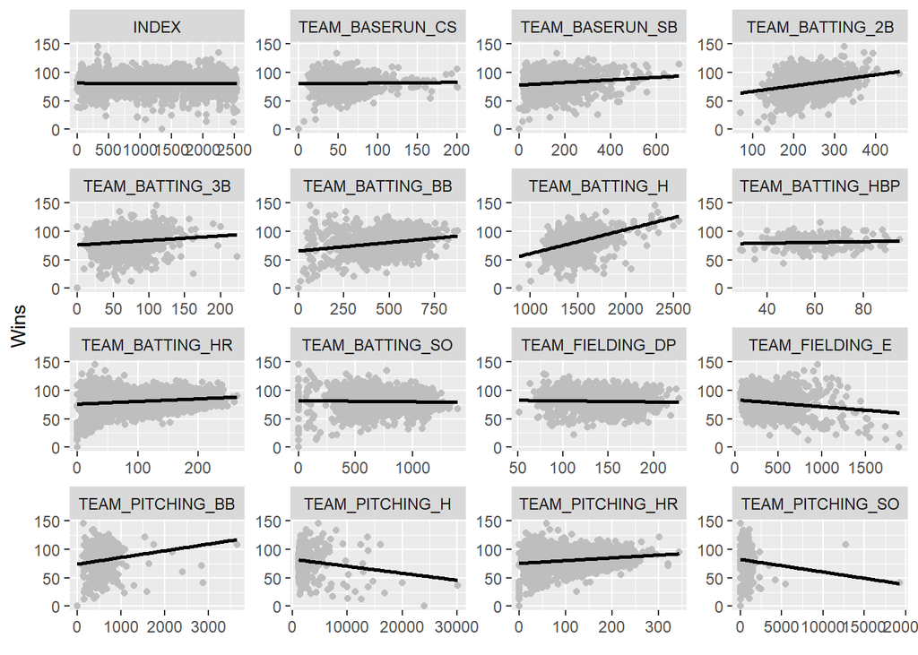

```r
training %>%
  gather(variable, value, -TARGET_WINS) %>%
  ggplot(., aes(value, TARGET_WINS)) +
  geom_point(fill = "indianred4", color="grey") +
  geom_smooth(method = "lm", se = FALSE, color = "black") +
  facet_wrap(~variable, scales ="free", ncol = 4) +
  labs(x = element_blank(), y = "Wins")
```

### Variable chacteristics

Each variable is presented below with corresponding basic statistics (minimum, median and maximum values, mean and standard deviation, number of records with missing values), boxplot, density plot with highlighted mean value, and scatterplot against outcome variable (`TARGET_WINS`) with best fit line. This information is used to check general validity of data and adjust as necessary.